# Results from MOVICS

Train**: TCGA RNAseq-CNV-Methylation-miRNA-SNPs | **Evaluation**: transNEO

Aris Sionakidis

2024-09-06

Abstract

In this markdown document, we present the main results of the MOVICS algorithm ([Ref](https://academic.oup.com/bioinformatics/article/36/22-23/5539/6033582)). MOVICS is used to perform multi-omics integrative clustering and visualization for cancer subtyping research. It provides a unified interface for 10 state-of-the-art multi-omics clustering algorithms, and standardizes the output for each algorithm so as to form a pipeline for downstream analyses. Ten algorithms are CIMLR, iClusterBayes, MoCluster, COCA, ConsensusClustering, IntNMF, LRAcluster, NEMO, PINSPlus, and SNF, where the former three methods can also perform the process of feature selection. For cancer subtyping studies, MOVICS also forms a pipeline for most commonly used downstream analyses for further subtype characterization and creates editable publication-quality illustrations. MOVICS suggests an estimate of the optimal number of multi-omic clusters $k$.

# Details on the algorithm

The first part of this pipeline is to **identify the ideal number of multi-omic clusters** in our data. For this, we use the `getClustNum()` function. Each dataset is normalized to ensure that data values are on the same scale. This involves setting negative values to zero (by adjusting them based on the minimum value), and scaling all values to a maximum of one. The function uses the `IntNMF::nmf.opt.k` method from the IntNMF package to compute the cluster prediction index for a range of cluster numbers (`try.N.clust`). This method performs NMF, which is used to reduce dimensionality and detect patterns in multi-omics data, and estimates the quality of clustering for each possible number of clusters by assessing the stability of clusters across multiple runs. This way, the **Cluster Prediction Index (CPI)** is estimated.

For each modality $i$ the NMF equation is:
$$X_{n \times p_{i}}^i \approx
W_{n \times k} H_{k \times p_{i}}^i$$

where $n$ is the number of samples, $p_i$ is the dimensionality of modality $i$ and $k$ a pre-defined number of clusters. The idea is that $W$ is the same for all modalities (matrix of basis vectors) and $H$ is varying (matrix of coefficients) - [link for paper](https://journals.plos.org/plosone/article?id=10.1371/journal.pone.0176278).

The objective function is:

$$Q = \min_{W, H} \sum_{i=1}^m \theta_{i}
||X^i - WH^i||_2$$

where $\theta_{i}$ is the user specified weight for $i-$th data. For example, the weights can be calculated as the maximum of the mean sums of squares among all data divided by the mean sums of squares of each data:

$$\theta_i =
\frac{\text{Max}\{\text{mean}\{\|X^i\|_2\}\}}{\text{mean}\{\|X^i\|_2\}},
\quad i = 1, \ldots, m$$
Thus, the use of $\theta$ ensures that the factorization process is more equitable, i.e. no single dataset with large scale or high variability unduly dominates the factorization process.

The function $Q$ is convex with respect to W; however, the function is not convex when $W$ and all $H^i$ are considered together. Therefore, there is no unique global minimum of the NMF problem. However, a local optimum can be achieved by minimizing the objective function Q using numerical optimization methods.

Overview of the algorithm:

1. $W$ is initialized from a random uniform distribution ($U$[0,1]) and/or using non-negative double singular value decomposition ([NNDSVD](https://www.sciencedirect.com/science/article/pii/S0031320307004359?via%3Dihub))
2. Solve for each $H^i$ using the [non-negativity constrained alternating least square (NNALS) algorithm was first proposed by Lawson & Hanson](https://www.semanticscholar.org/paper/Solving-least-squares-problems-Lawson-Hanson/b35e036e0226d923d03c06ae393084b40c9dec7e) and the current value for $W$:
   $$Q_{H^i} =
   \text{arg}\min_{H^i} ||X^i - WH^i||_2$$
3. Solve for $W$ using $X^i$ and the current values for $H^i$ ($i = 1, \ldots, m$) using NNALS:
   $$Q_W =
   \text{arg}\min_{W} \sum_{i=1}^m \theta_{i} ||X^i - WH^i||_2$$
4. Repeat Step 2 and 3 until convergence

Using the solution for $W$, the cluster membership for each sample is then determined by the highest entry in each column (i.e., sample $j$ is assigned in cluster $c$ if $W[j, c]$ is the largest element in $W[j,]$ where $j$ represents rows, $j = 1,\ldots,n$, and $c$ represents columns in $W, c = 1,\ldots,k$.

The stopping criterion in the algorithm is based on the stability in connectivity matrix. For each run of the algorithm, a $n \times n$ connectivity matrix $C$ with all the entries either 0 or 1 is defined based on the sample assignment to the clusters. If two samples $i$ and $j$ belong to the same cluster then the corresponding entry of the connectivity matrix is 1 ($c_{ij} = 1$) otherwise it is 0 ($c_{ij} = 0$). The algorithm stops when $C$ does not change for a pre-set number of consecutive iterations (100 in MOVICS).

The optimal $k$ is determined based on the CPI using a resampling-based cross-validation technique.

**More on CPI**

Τhe idea is to partition the data into training ($Χ^i_{n1 \times p_i}$, for $i = 1,\ldots,m$) and testing ($Χ^i_{n2 \times p_i}$, for $i = 1,\ldots,m$) sets repeatedly. At each repetition, the intNMF algorithm is applied to the training data in order to estimate coefficient matrices $H^i_{k \times p_i{\text{(train)}}}$} ($i = 1,\ldots, m$). The coefficient matrices are then used to estimate the common basis matrix ($W_{n2 \times k}$) using the test data and solving the following optimization problem:

$$Q_{W_{n2 \times k}} =
\text{arg}\min_{W_{n2 \times k}} \sum_{i=1}^m \theta_{i} ||X^i_{n2
\times p_i} - W_{n2 \times k}H^i_{k \times
p_i{\text{(train)}}}||_2$$

Cluster memberships of the samples in the test data are predicted using the matrix as mentioned before. In parallel, intNMF algorithm is used in the test data independently to compute the clustering assignments (“observed”) of the samples in test data. Under the true model, there should be a good consensus between the predicted and the observed clustering assignments as measured by the adjusted rand index. The process is repeated several times and average of the adjusted rand indices is computed which is called “Cluster Prediction Index”. The value of k that results in maximum value of Cluster Prediction Index (CPI) is chosen as optimum number of clusters for the data.

The function also computes **gap statistics** using the `mogsa::moGap()` method after performing Multiple Omics data integrative Cluster Analysis (MOCA) with `mogsa::mbpca()`.

The function `mogsa::mbpca()` is called with the following parameters on a set of matrics $x$:

1. **Normalization**
   Each matrix $X$ in $x$ is transposed and then processed according to the specified options for centering and scaling. For `center = TRUE` and `scale = TRUE`, the transformation is:
   $$X'_{ij} =
   \frac{X_{ij} - \mu_j}{\sigma_j}$$
   where $\mu_j$ is the mean of the $j^{th}$ column, and $\sigma_j$ is the standard deviation of the $j^{th}$ column of matrix $X$.
2. **SVD Solver Configuration**
   The SVD of a matrix $X'$ is computed as:
   $$X' = U \Sigma V^T$$
   where $U$ and $V$ are orthogonal matrices containing the left and right singular vectors, respectively, and $\Sigma$ is a diagonal matrix containing the singular values. Principal components are calculated on the concatenated matrices from different modalities (`method = 'globalScore'` in `mbpca()` -> can be switched to `'blockScore'` or `'blockLoading'` for computing principal components for each block independently but using information from other blocks to refine these calculations OR calculating loadings for each block that are influenced by the structure of the entire dataset, respectively).
3. **Weight Initialization (weights for different modalities)**
   Since weights are not provided and are initialized as NA, they default to 1:
   $$w = 1, \quad w_{\text{obs}} =
   1$$
4. **Component Calculation**
   For `ncomp = 2`, two components are calculated using the SVD function. Deflation is applied at each step (twice in this case in order to ensure components are orthogonal) using the method “globalScore”, which adjusts each block matrix $x_b$ in $x$ as follows:
   $$x_b' = x_b -
   \frac{tt^Tx_b}{t^Tt}$$
   where $t$ is the score matrix from the SVD, and $t^T$ is its transpose.
5. **Multi-Omics Analysis**  
   If `moa = TRUE`, the function integrates results across different types of omics data. This integration involves the computation of various diagnostics such as eigenvalues, factor scores, and contributions, as well as the RV coefficient for dataset similarity:

**More on RV**

- For each matrix $X$ in the data list, calculate the normalized cross-product matrix:
  $$M_X =
  \frac{X^TX}{\sqrt{\sum(X^TX)^2}}$$
  where $X^TX$ computes the cross-product of matrix $X$, representing the correlation matrix for the variables. The division by $\sqrt{\sum(X^TX)^2}$ normalizes the matrix to unit scale, which aids in comparing matrices of different scales or units.
- Compute the RV matrix, which is the cross-product of the normalized matrices for each dataset:
  $$RV = M_{s1}^T
  M_{s2}$$
  where $M_{s1}$ and $M_{s2}$ are the normalized cross-product matrices from datasets 1 and 2 ($X_1$ and $X_2$). The RV matrix elements represent the correlation between datasets, with each element measuring the similarity between pairs of datasets based on their variables. More specifically: Let $X$, $Y$ be two matrices corresponding to two datasets. The RV coefficient between these two datasets is calculated as:
  $$RV_{XY} = \frac{\text{trace}(X X^T Y
  Y^T)}{\sqrt{\text{trace}(X X^T X X^T) \times \text{trace}(Y Y^T Y
  Y^T)}}$$
- Extending this to four datasets, let’s denote them as $X_1$, $X_2$, $X_3$, and $X_4$. The resulting $RV$ matrix would be a 4x4 matrix, where each element $R_{ij}$ is the RV coefficient between $X_i$ and $X_j$:
  $$\textbf{R} = \begin{bmatrix}
  1 & \text{RV}_{X_1X_2} & \text{RV}_{X_1X_3} &
  \text{RV}_{X_1X_4} \\
  \text{RV}_{X_2X_1} & 1 & \text{RV}_{X_2X_3} &
  \text{RV}_{X_2X_4} \\
  \text{RV}_{X_3X_1} & \text{RV}_{X_3X_2} & 1 &
  \text{RV}_{X_3X_4} \\
  \text{RV}_{X_4X_1} & \text{RV}_{X_4X_2} & \text{RV}_{X_4X_3}
  & 1
  \end{bmatrix}$$
  Each non-diagonal element $R_{ij}$ is computed by the given $RV$ formula, and each diagonal element is 1, reflecting the perfect similarity of a dataset with itself.

Gap statistics compare the total within-cluster variation for different numbers of clusters against the expected variation under a reference null distribution that is generated using Monte Carlo simulations. This helps in identifying a clustering structure that has a significantly lower within-cluster variation compared to the null model.

- **Within-cluster sum of squares**:
  $$W_k(X, k) = 0.5 \times \sum_{j=1}^{k}\sum_{i\in
  C_{j}}{\left( \frac{d(x_i, \mu_j)^d}{|C_j|} \right)}$$
  where $C_j$ is the set of indices belonging to cluster $j$, $x_i$ are the data points, $\mu_j$ is the centroid of cluster $j$, $d = 1$ by default.
- The logarithm of $W_k(X, k)$ is computed for each
  $$k \in \{2, 3, \ldots,
  10\}, k \in \mathbb{N}$$
  :
  $$\log W[k] = \log
  W_k(X,k)$$
- **Bootstrapping for Null distribution**: By default, $B=100$ bootstrap samples $z$ are generated to create a reference distribution in order to estimate $E[\log W[k]]$. The process takes into account the range of features in $X$ and uses principal component information to preserve the structure of $X$ in the bootstrap samples.
  $$\log W_{bk}(b, k) = \log W(z, k)$$
  $$E[\log W[k]] = \frac{1}{B} \sum_{b=1}^B{\log
  W_{bk}}$$
  for a specific value of $k$.
- Calculation of the gap statistic:
  $$Gap[k] = E[\log W[k]] - \log W_k$$

The function identifies the optimal number of clusters by combining the results from the CPI and the gap statistics. It computes the sum of the normalized values from both metrics for each cluster number and identifies the number where this sum is maximized.

# Hyperparameters and tuning

Here, we run the MOVICS pipeline (see [here](https://xlucpu.github.io/MOVICS/MOVICS-VIGNETTE.html)) using the default parameters. When identifying the optimal number of clusters $k$, we try for $k \in \{2, \ldots, 10\}$. All algorithms are run with default parameters, apart from `iClusterBayes` where we set `n.burnin = 1800` and `n.draw = 1200`, to reduce running times. The consensus multi-omic clustering algorithm is run for the optimal $k$ only.

# Main results on training data

## Optimal number of clusters

The optimal number of clusters according to MOVICS is $k = 2$.

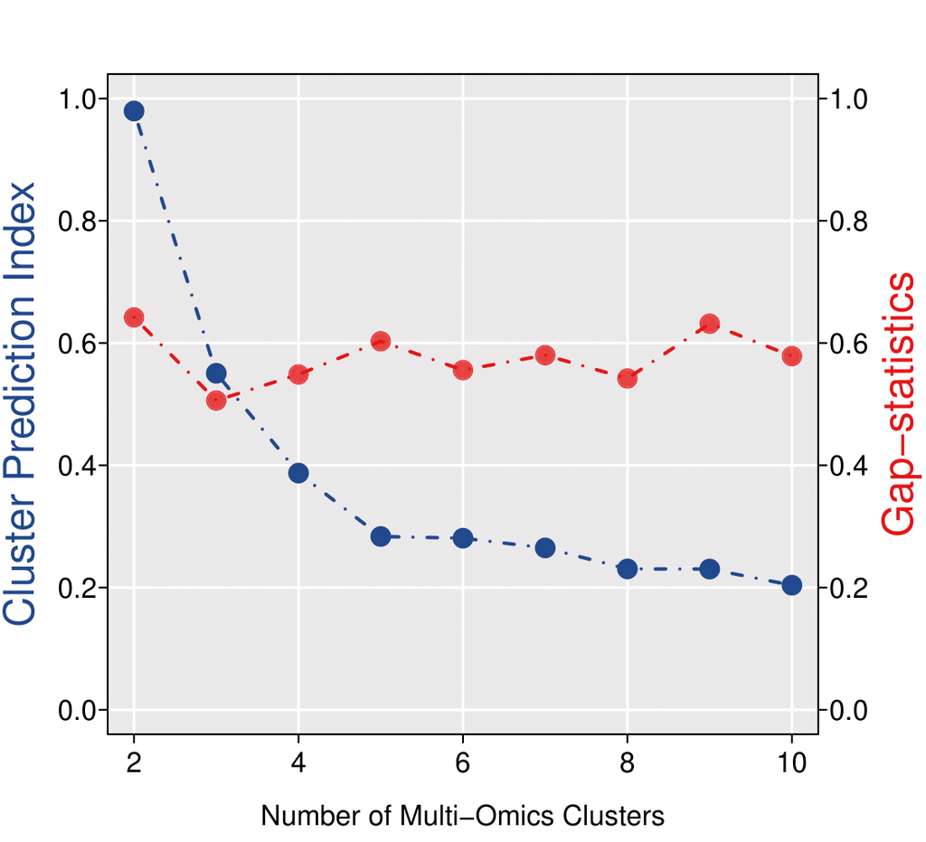

The multi-omics consensus clustering results for $k = 2$ are shown below (pairwise distances heatmap):

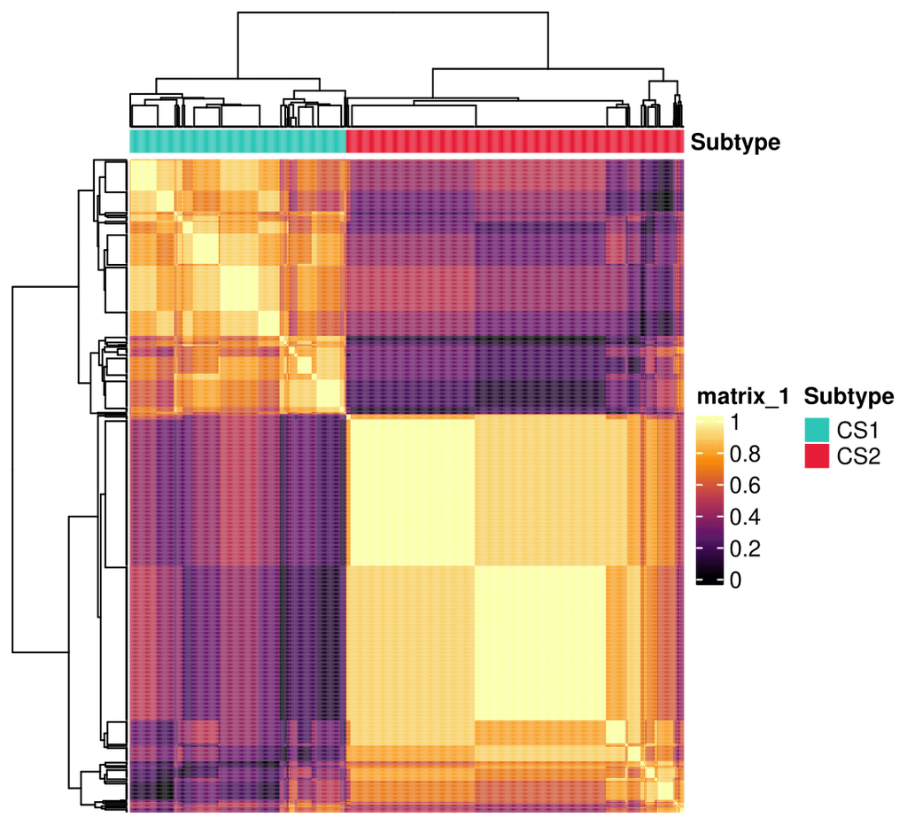

Below are the silhouette metrics for the 2 clusters:

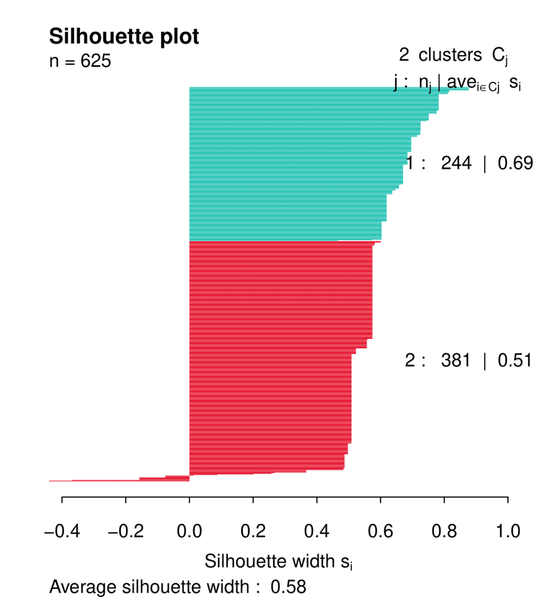

Comprehensive multi-omics heatmap and clusters:

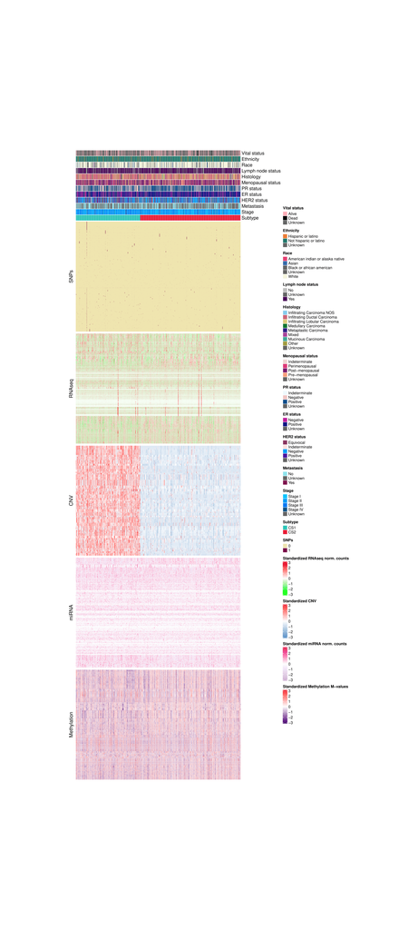

## Clinical variables

With respect to clinical variables statistically significant associations were found between the consensus subtypes and **vital status, history of neoadjuvant treatment, histological type, PR status, ER status, HER2 status, and ER and PR cell level percentages**. Results can be found in the summary file.

## Mutations

The MOVICS package provides a function `compMut()` which applies independent testing (i.e., Fisher’ s exact test or $\chi^2$ test) for each mutation, and generates a table with statistical results and creates an OncoPrint using those differentially mutated genes.

**Oncoprint:**

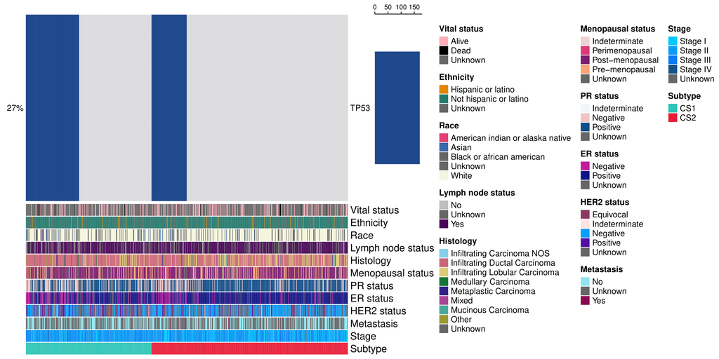

## Differential Gene Expression Analysis (DGEA)

In order to identify subtype-specific markers, we find the markers that are up-regulated in CS1 vs. all other clusters and the ones which are down-regulated in CS1 vs. all other clusters etc.

In this procedure, the most differentially expressed genes sorted by **log2FoldChange** are chosen as the biomarkers for each subtype (200 biomarkers for each subtype by default; Here we set 200 -> **100 markers**). These biomarkers should pass the significance threshold (e.g., nominal $p-$value < 0.05 and adjusted $p-$value < 0.05) and must not overlap with any biomarkers identified for other subtypes.

**Up-regulated markers**

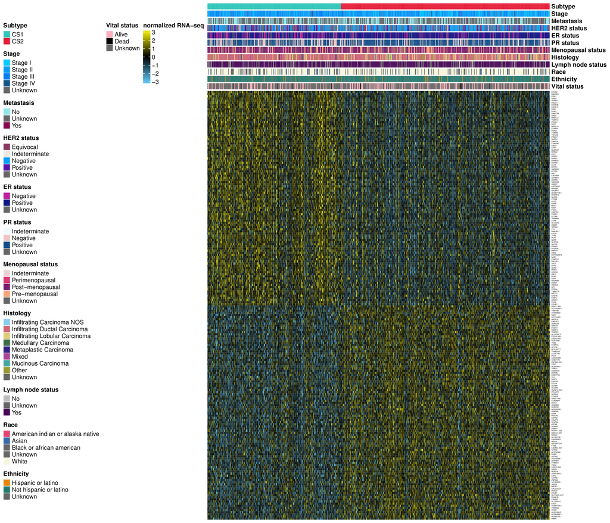

## Gene Set Enrichment Analysis

GSEA is carried out using a gene set background which includes all gene sets derived from GO biological processes (c5.bp.v7.1.symbols.gmt) from The Molecular Signatures Database (MSigDB, https://www.gsea-msigdb.org/gsea/msigdb/index.jsp).

Likewise, these identified specific pathways should pass the significance threshold (e.g., nominal $p-$value < 0.05 and adjusted $p-$value < 0.25; we set the latter to 0.1) and must not overlap with any pathways identified for other subtypes. After having the subtype-specific pathways, genes that are inside the pathways are retrieved to calculate a single sample enrichment score by using `GSVA` R package. Subsequently, subtype-specific enrichment score will be represented by the mean or median (mean by default) value within the subtype, and will be further visualized by diagonal heatmap.

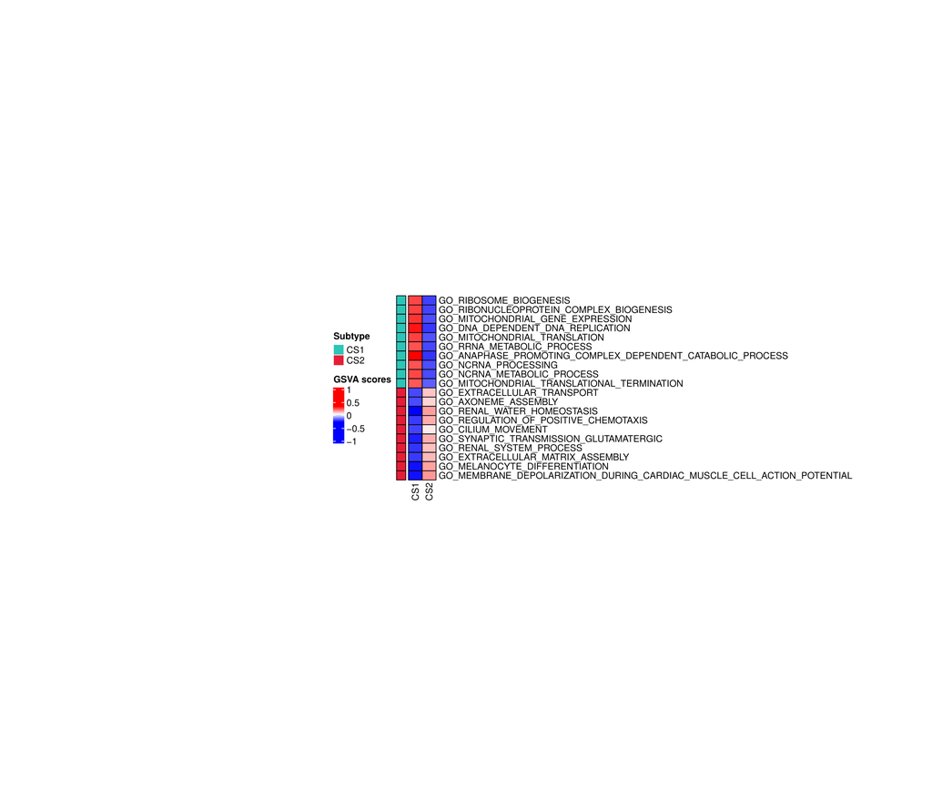

For all the new defined molecular subtypes, it is critical to depict its characteristics validated by different signatures of gene sets. MOVICS provides a simple function which uses gene set variation analysis to calculate an enrichment score for each sample in each subtype based on given gene set list of interest.

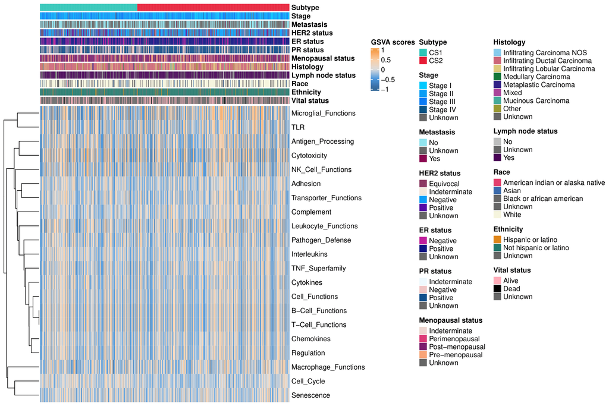

# Evaluation results

## Nearest Template Prediction (NTP)

MOVICS provides two model-free approaches for subtype prediction in validation cohort. First, MOVICS switches to nearest template prediction ([NTP](https://pubmed.ncbi.nlm.nih.gov/21124904/)) which can be flexibly applied to cross-platform, cross-species, and multiclass predictions without any optimization of analysis parameters.

Here cosine similarity is used to compare external samples to class templates (here we use the up-regulated genes in the form of a binary matrix with two columns: cluster 1 / cluster 2 where an entry is 1 if the gene is up-regulated in the cluster or -1 otherwise). The nearest class for each sample is determined by the smallest distance (converted from cosine similarity here). Each sample’s result includes the nearest class prediction, the distance to all templates, and the p-value of the prediction.

The function randomly permutes the sample labels multiple times (here `nPerm = 10000`) to generate a null distribution of similarity scores between samples and class templates. For each observed sample-to-template distance, the function compares it against the null distribution to calculate a p-value. This p-value indicates the likelihood that the observed match could have occurred by chance. The p-values are adjusted using the false discovery rate (FDR) method to control for multiple hypothesis testing, ensuring robust statistical inference.

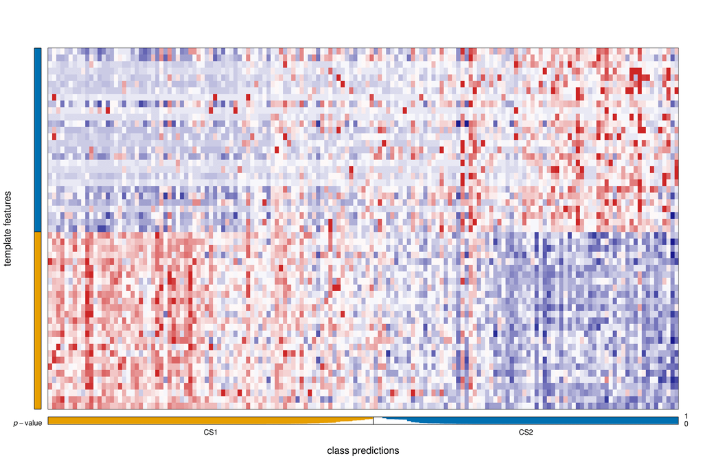

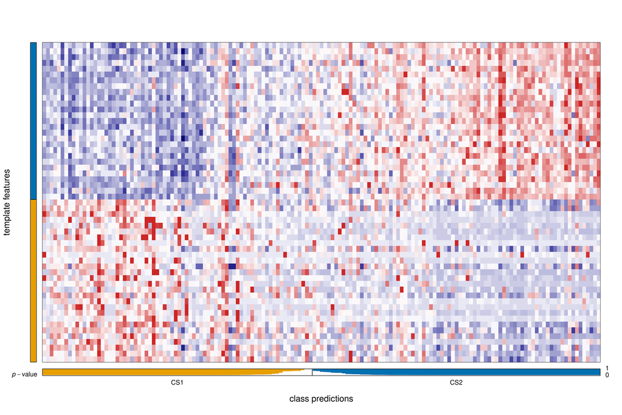

Results on the comparisons of transNEO clinical variables with respect to the predicted consensus subtypes are summarised in this file.

## Partition Around Medoids (PAM)

To be specific, `runPAM()` first trains a partition around medoids (PAM) classifier in the discovery (training) cohort (i.e., TCGA) to predict the subtype for patients in the external validation (testing) cohort (i.e., transNEO), and each sample in the validation cohort was assigned to a subtype label whose centroid had the highest Pearson correlation with the sample. Finally, the [in-group proportion (IGP)](https://pubmed.ncbi.nlm.nih.gov/16613834/) statistic (the proportion of samples within a cluster that were classified into the same cluster upon random permutation of the data) is estimated to evaluate the similarity and reproducibility of the acquired subtypes between discovery and validation cohorts (i.e. are the clusters identified in TCGA reproducible in transNEO after label permutation).

Compare consensus TCGA vs. PAM TCGA (other comparisons not possible):

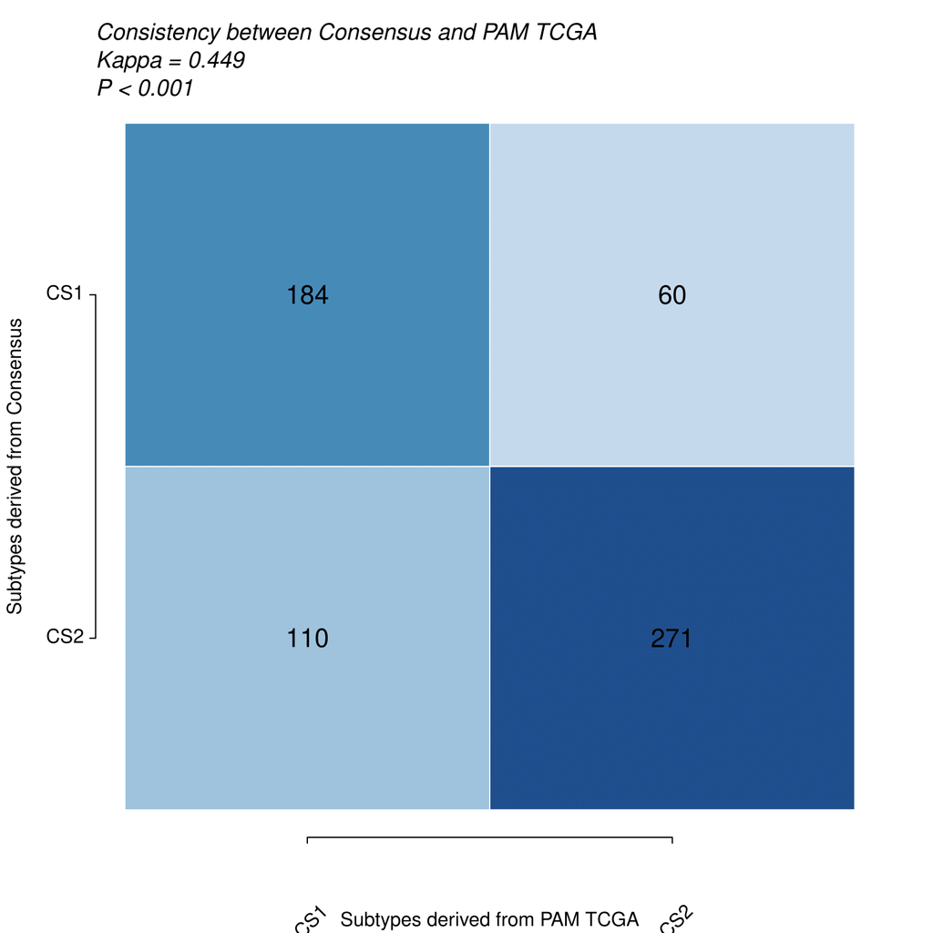

## Clinical variables in transNEO

The predicted CS1 and CS2 subtypes on transNEO are associated with **Lymph node status at diagnosis, ER status, Grade, pCR (more responders in CS1), PAM50, iC10, RCB score, STAT1.gsva score, GGI.gsva score, ESC.gsva score, TMB and HRD.sum**.

# Supplementary results

## Drug Sensitivity

We also perform a few drug sensitivity comparisons. MOVICS uses the pRRophetic package for prediction of clinical chemotherapeutic response from tumor gene expression levels (a pre-trained ridge regression model is fit for each gene and the $IC_{50}$ of each drug).

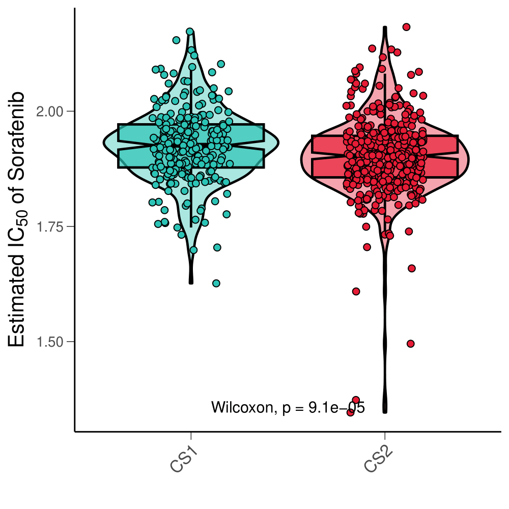

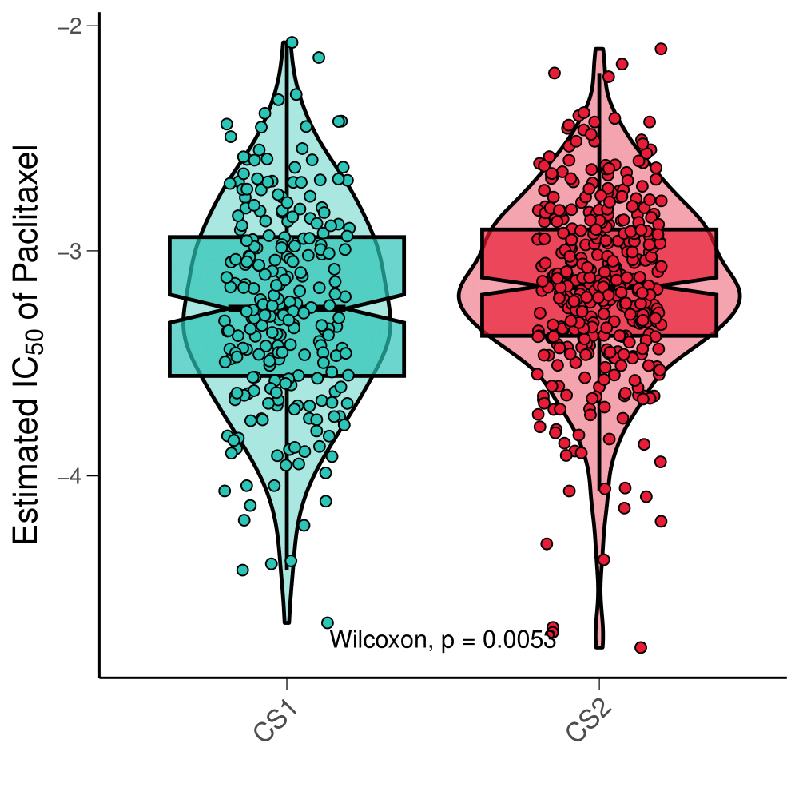

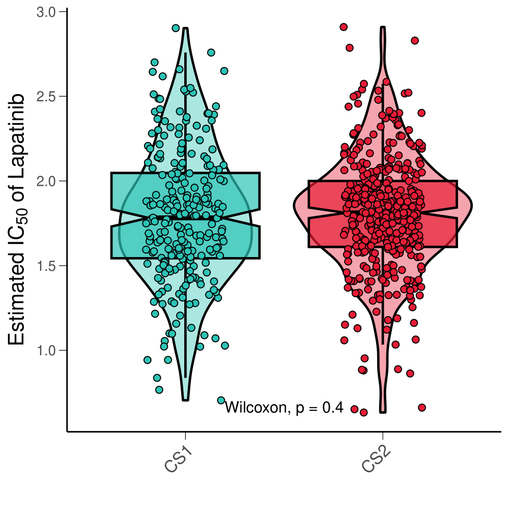

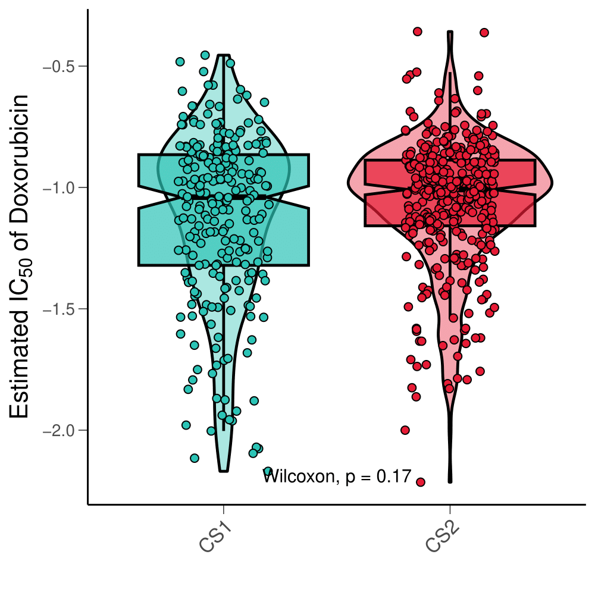

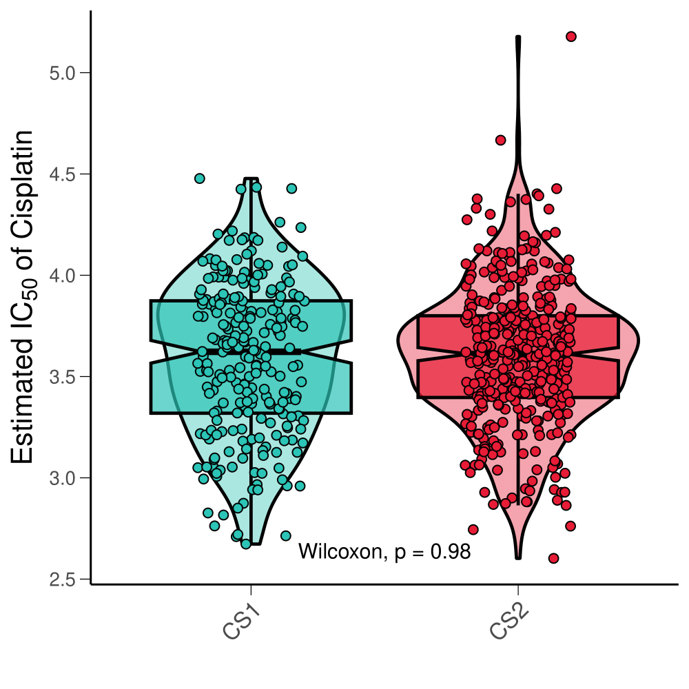

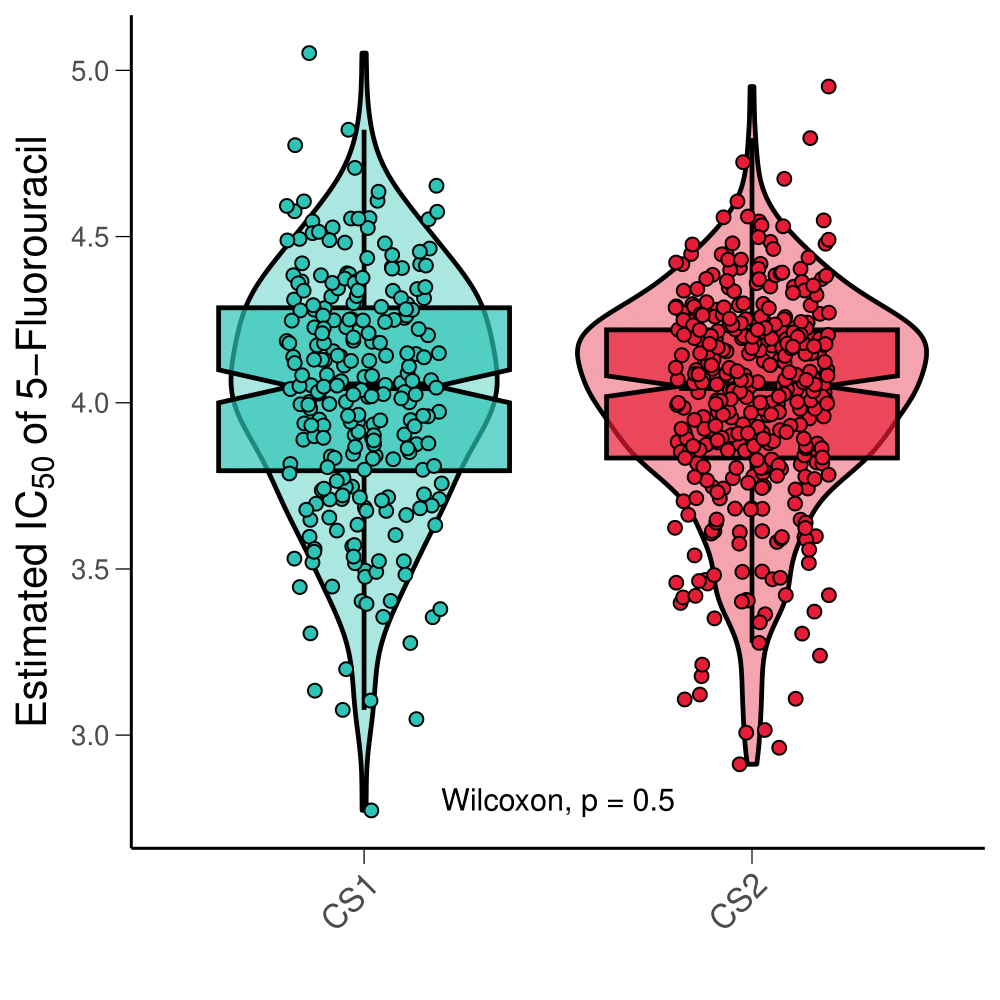

## Subtype agreement

Here we examine how similar the consensus multi-omic clustering labels are to other labels relative to breast cancer.

MOVICS provides function of `compAgree()` to calculate four statistics: Rand Index (RI), Adjusted Mutual Information (AMI), Jaccard Index (JI), and Fowlkes-Mallows (FM); all these measurements range from 0 to 1 and the larger the value is, the more similar the compared groups are.

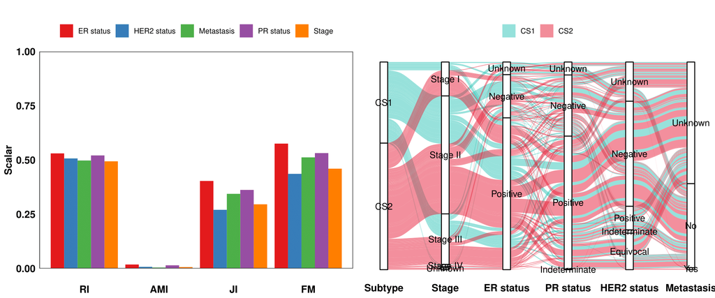

# Conclusions

1. There are 2 predicted clusters (consensus subtypes) in the TCGA cohort.
2. There are **244 CS1 samples and 381 CS2 samples**.
3. Special findings about different consensus subtypes:
   - CS1 has 77.5% IDC samples, while CS2 has 64.8%. CS1 has 11.5% ILC, while CS2 has 23.6%.
   - **63.5% of CS1 samples are ER+**, while **79.3% of CS2 samples are ER+**.
   - **54.5% of CS1 samples are PR+**, while **70.1% of CS2 samples are PR+**.
   - CS1 is associated with increased predicted sensitivity to **paclitaxel** and decreased predicted sensitivity to **sorafenib**.
   - Oncoprint showed association of CS1 with *TP53* mutations.
4. CS1 and CS2 labels in transNEO are associated with clinical variables of interest. With respect to **pCR**:

Response rates across transNEO CS subtypes

| Response | CS1 | CS2 |
| --- | --- | --- |
| pCR | 31 ( 39.2%) | 10 ( 13.5%) |
| Residual Disease | 48 ( 60.8%) | 64 ( 86.5%) |